# model

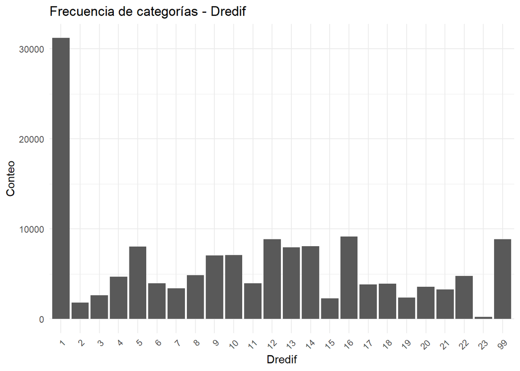

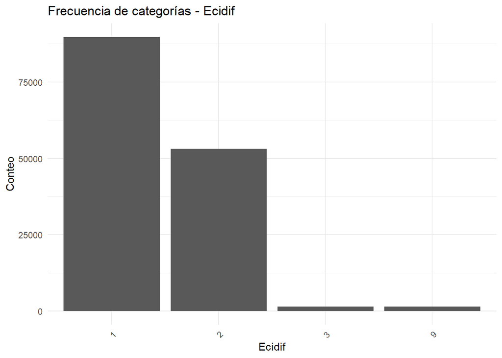

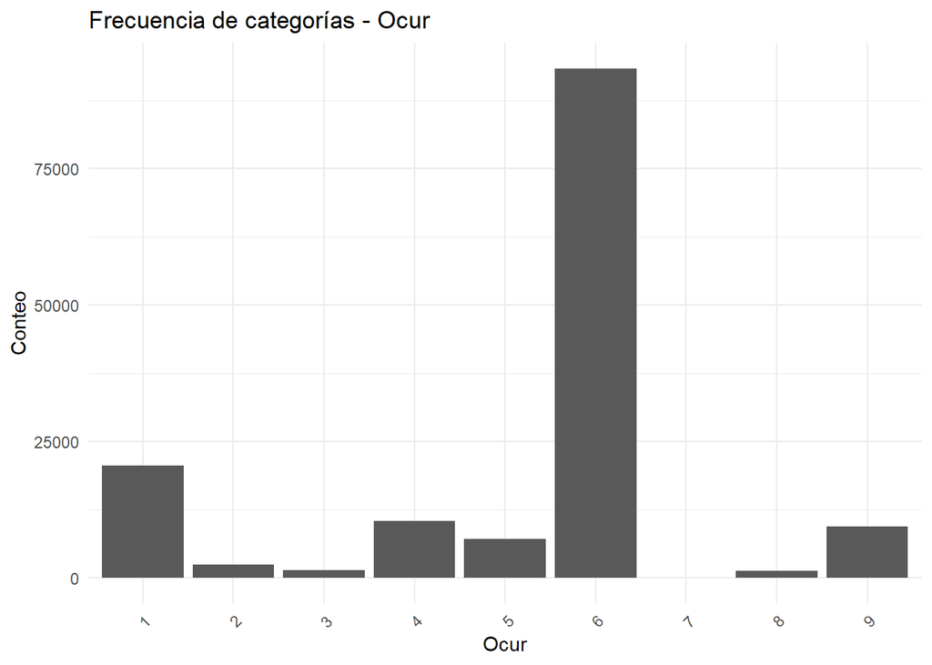

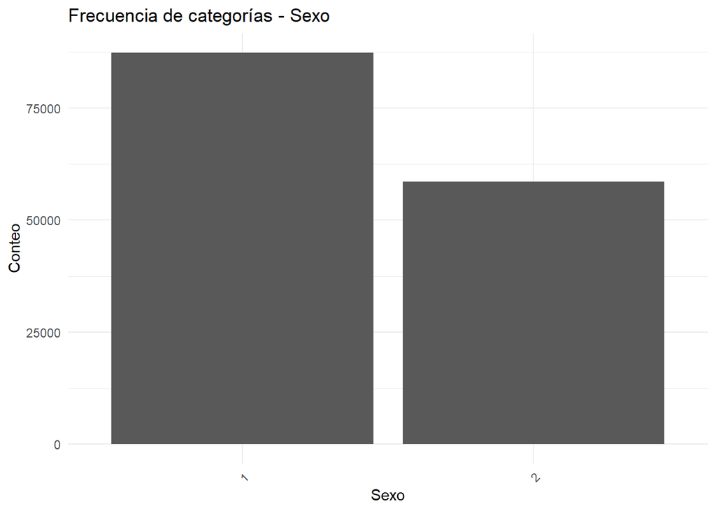

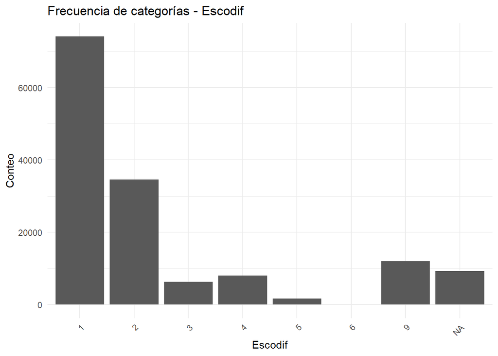

Para el pre-procesamiento hay bastantes cosas a tener en cuenta. Lo primero es la ditribución de los datos. En tabla de distribución se pueden ver cosas interesantes como cuales son los datos más repetidos, casos atípicos e incluso la cantidad de valores vacíós. Como se puede ver la única tabla de frecuencia con NA’s es la de el nivel de escolairdad. Por lo que será necesario procesarlos. Afortunadamente, en el diccionario de variables, está definido que el valor 9 significa “Ignorado” osea que no se conoce el dato como tal. Entonces podemos reemplazar los NA con el número 9.

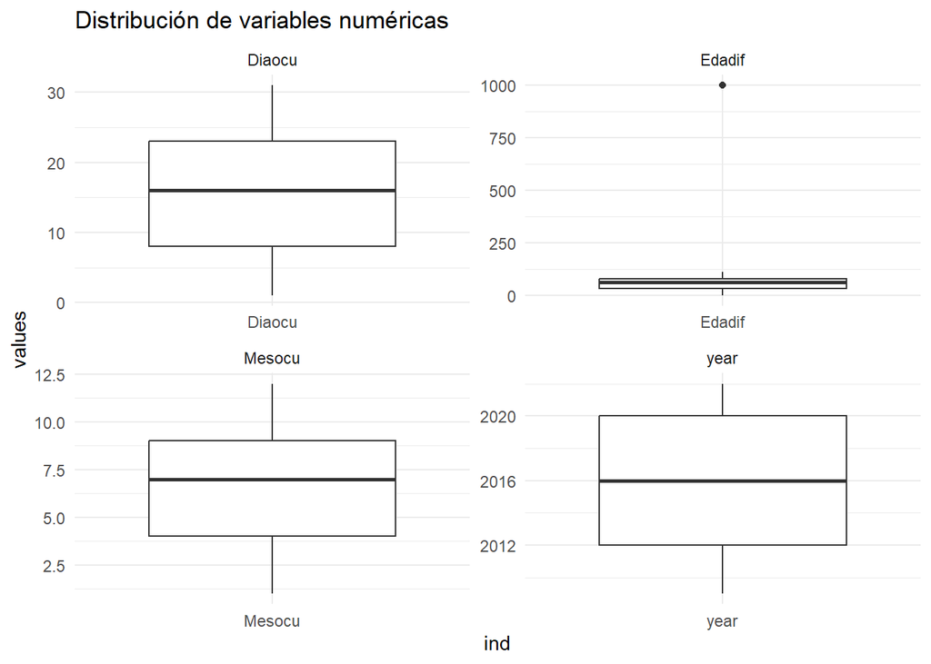

```
## Registros con Edadif en train = 999: 1174
## Porcentaje del total: 0.8 %
```

```
## Registros con Edadif en test = 999: 544
## Porcentaje del total: 0.87 %
```

```
##       Asist      Depocu      Diaocu      Dnadif      Dredif      Ecidif
##           0           0           0           0           0           0
##      Edadif      Mesocu        Ocur        Sexo        year     Escodif
##           0           0           0           0           0        9252
## causa_macro
##           0
```

```
##       Asist      Depocu      Diaocu      Dnadif      Dredif      Ecidif
##           0           0           0           0           0           0
##      Edadif      Mesocu        Ocur        Sexo        year     Escodif
##           0           0           0           0           0        4008
## causa_macro
##           0
```

```
##       Asist      Depocu      Diaocu      Dnadif      Dredif      Ecidif
##           0           0           0           0           0           0
##      Edadif      Mesocu        Ocur        Sexo        year     Escodif
##           0           0           0           0           0           0
## causa_macro
##           0
```

```
##       Asist      Depocu      Diaocu      Dnadif      Dredif      Ecidif
##           0           0           0           0           0           0
##      Edadif      Mesocu        Ocur        Sexo        year     Escodif
##           0           0           0           0           0           0
## causa_macro
##           0
```

```
## [1] "Matriz de correlación (Train):"
```

```
##             Diaocu      Edadif     Mesocu        year
## Diaocu 1.000000000 0.005248147 0.02126514 0.002905493
## Edadif 0.005248147 1.000000000 0.02897924 0.130698607
## Mesocu 0.021265142 0.028979236 1.00000000 0.018941560
## year   0.002905493 0.130698607 0.01894156 1.000000000
```

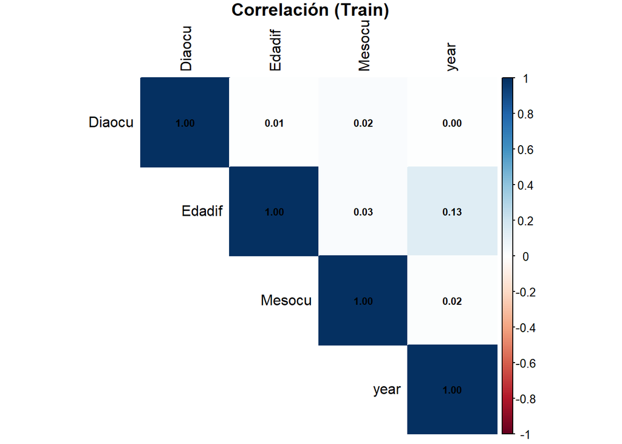

Se realizó también la tabla de correlación de variables con el fin de poder ver si el algoritmo podría verse afectado por variables altamente correlacionadas. Al final realmente hemos limitado correctamente las variables, evitando alta correlación y redundancia que ppudiera generar ruido. Habiendo terminado el Pre procesamiento ahora se puede empezar con algunas transformaciones y el entrenamiento.

## Entrenamiento

```
## K obtenido con la raiz de la cantidad de registros: 120
```

```
## Confusion Matrix and Statistics
##
##                                  Reference
## Prediction                        Causas externas Crónicas Infecciosas
##   Causas externas                             862      176         262
##   Crónicas                                     22       76          66
##   Infecciosas                                 125      232         602
##   Neoplasias                                  173      519         183
##   Síntomas y causas mal definidas              56      241         118
##                                  Reference
## Prediction                        Neoplasias Síntomas y causas mal definidas
##   Causas externas                        100                             101
##   Crónicas                                98                              50
##   Infecciosas                            148                             115
##   Neoplasias                             677                             356
##   Síntomas y causas mal definidas        226                             618
##
## Overall Statistics
##
##                Accuracy : 0.4571
##                  95% CI : (0.4447, 0.4696)
##     No Information Rate : 0.2014
##     P-Value [Acc > NIR] : < 2.2e-16
##
##                   Kappa : 0.3213
##
##  Mcnemar's Test P-Value : < 2.2e-16
##
## Statistics by Class:
##
##                      Class: Causas externas Class: Crónicas Class: Infecciosas
## Sensitivity                          0.6963         0.06109            0.48903
## Specificity                          0.8713         0.95240            0.87528
## Pos Pred Value                       0.5743         0.24359            0.49264
## Neg Pred Value                       0.9200         0.80170            0.87369
## Prevalence                           0.1996         0.20058            0.19848
## Detection Rate                       0.1390         0.01225            0.09707
## Detection Prevalence                 0.2420         0.05031            0.19703
## Balanced Accuracy                    0.7838         0.50675            0.68215
##                      Class: Neoplasias Class: Síntomas y causas mal definidas
## Sensitivity                     0.5420                                0.49839
## Specificity                     0.7515                                0.87082
## Pos Pred Value                  0.3548                                0.49087
## Neg Pred Value                  0.8668                                0.87417
## Prevalence                      0.2014                                0.19994
## Detection Rate                  0.1092                                0.09965
## Detection Prevalence            0.3076                                0.20300
## Balanced Accuracy               0.6467                                0.68460
```

[figure not shown]

Para este primer modelo lo que se buscó fue convertir las columnascategóricas a factores.Lo clave aquí es que forzamos al conjunto de prueba a usar los mismos niveles que el de entrenamiento, así evitamos errores raros después al momento de realizar la matriz de confusión o procesar los datos en general. Usamos un sample del data set ya que los datos son demasiado el tiempo de ejecución creacía demasiado y el debuggeo y entrenamiento se hacía demasiado largo. Pero al final conseguimos los resultados, usando una muestra que mantenía también el balance entre las clases. Además de la muestra escalamos los números de las distintas columnas para que todas se encuentren en un mismo rango, algo muy importante para el algoritmo KNN.

```
## Accuracy en Train: 0.4677
## Accuracy en Test: 0.4571
## Diferencia: 0.0106
```

Luego del entrenamiento se evalú el accuracy tanto con el set de prueba como con el set de entrenamiento. Esto con el fin de verificar la presencia de overfitting. Como podemos ver este primer modelo usando un K con la ráiz de la cantidad de registros para el entrenamiento. El desempeño realmente es un tanto bajo. Aunque bien tenemos 5 clases predictorias, en teoría si la clasificación fuera al azar, cada uno tendría un 20% de probabilidad. Técnicamente nuestra clasificación es mucho mejor que la clasificación aleatoria, alcanzando un 45% de accuracy, pero puede que hayan problemas con alguna de las clases. Al menos se puede ver que el modelo no se encuentra sobreajustado con ese parámetro de K.

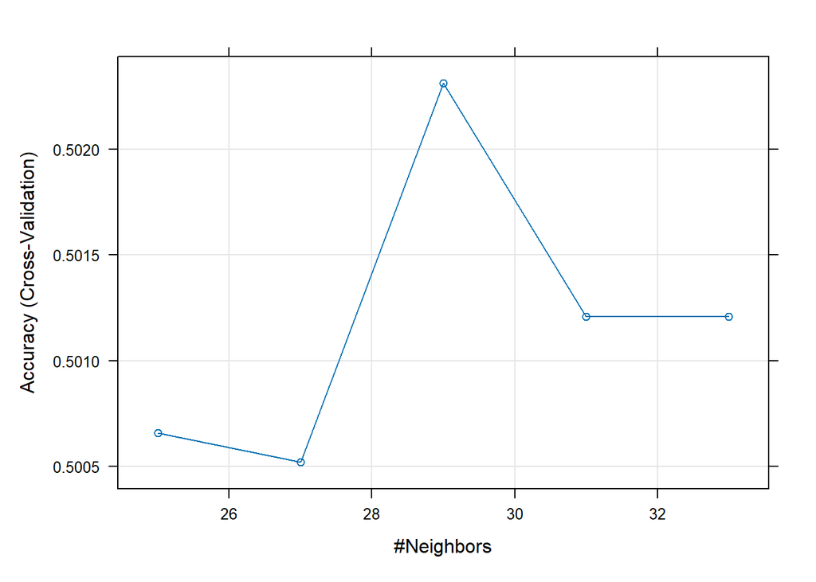